# MP2

Jonah Kotzen, Scarlett Varley, Ariana Roberts

2024-02-14

# Introduction

This project works to uncover how skeletal geometry and muscle length and mass affect both the force output in the forelimb and the maximum load it can support. The project aims to predict how much force and torque are produced by the biceps system over a range of extension/flexion angles, assess how force and torque vary according to extension/flexion angle, and test these predictions in the gym. The question will be answered through computational analysis of torque, force, and maximum mass at respective angles with the measurements of arm length, inlever length, outlever length, and weight of bicep.

# Methods

Arm length, inlever length, and outlever length were measured in lab using a meter stick. Bicep weight was predicted by weighing play-dough and approximating the size of each participant’s bicep muscle. Computational analysis is as follows usuing the Hill-type muscle model (Hill 1938). Additionally, we utilized the relationship approximation between force and muscle length for mammalian skeletal muscle (Whiting and Herzog 1999).

### Dataset for 3 Subjects (Jonah, Scarlett, Ari)

```r
print(arm_dat)
```

```
## # A tibble: 3 × 5
##   subject   Larm    Li  Lout Mmuscle
##   <chr>    <dbl> <dbl> <dbl>   <dbl>
## 1 Jonah    0.315 0.085 0.326   0.323
## 2 Scarlett 0.32  0.058 0.287   0.241
## 3 Ariana   0.265 0.054 0.276   0.165
```

### Functions for Calculations

```r
law_cos <- function(l, r, o) {
  theta <- acos((-o^2 + l^2 + r^2) / (2 * l * r))
  return(theta)
}

law_cos2 <- function(l, r, theta) {
  o <- sqrt(l^2 + r^2 - 2 * l * r * cos(theta))
  return(o)
}

force_length_factor <- function(Lmuscle, Lmuscler) {
  Lopt <- Lmuscler * 0.8
  ffl <- -6.25 * (Lmuscle / Lopt)^2 + 12.5 * (Lmuscle / Lopt) - 5.25
  return(ffl)
}

calculate_Fmax <- function(Mmuscle, Lmuscler, rho = 0.00105, phi = 0, k = 80) {
  PCSA <- (Mmuscle * cos(phi)) / (rho * Lmuscler)
  Fmax <- PCSA * k
  return(Fmax)
}
```

### The Model Function

```r
model <- function(Mmuscle, Lmuscler, Lmuscle, theta, Li, rho = 0.00105, k = 80) {
   # Convert Lmuscler from m to cm for PCSA calculation (as ρ is given in kg/cm^3)
  Lmuscler_cm <- Lmuscler * 100
  # Assuming phi is 0 as the muscle is nonpennate
  phi <- 0
  # PCSA calculation
  PCSA <- (Mmuscle * cos(phi)) / (rho * Lmuscler_cm)
  # Fmax calculation
  Fmax <- PCSA * k
  # Force-length relationship factor (ffl)
  ffl <- force_length_factor(Lmuscle, Lmuscler)
  # Muscle force (Fmuscle)
  Fmuscle <- Fmax * ffl
  # Torque calculation (τmuscle)
  tau_muscle <- Fmuscle * sin(theta) * Li
  return(tau_muscle)
}
```

# Results

### Final Tibble

```r
print(dat)
```

```
## # A tibble: 15 × 6
##    subject  flexion_rad Lmuscle theta muscle_torque max_mass
##    <chr>          <dbl>   <dbl> <dbl>         <dbl>    <dbl>
##  1 Jonah          0.873   0.268 2.02          42.1     13.2
##  2 Jonah          1.31    0.304 1.56          53.3     16.7
##  3 Jonah          1.75    0.340 1.15          46.5     14.5
##  4 Jonah          2.18    0.370 0.771         29.4      9.20
##  5 Jonah          2.62    0.391 0.415         13.2      4.11
##  6 Scarlett       0.873   0.286 2.11          24.4      8.67
##  7 Scarlett       1.31    0.310 1.65          28.3     10.1
##  8 Scarlett       1.75    0.335 1.22          24.3      8.63
##  9 Scarlett       2.18    0.356 0.826         15.9      5.63
## 10 Scarlett       2.62    0.371 0.445          7.54     2.68
## 11 Ariana         0.873   0.234 2.09          18.3      6.75
## 12 Ariana         1.31    0.256 1.63          21.5      7.95
## 13 Ariana         1.75    0.279 1.20          18.5      6.83
## 14 Ariana         2.18    0.299 0.812         11.9      4.41
## 15 Ariana         2.62    0.313 0.437          5.58     2.06
```

### Graphs

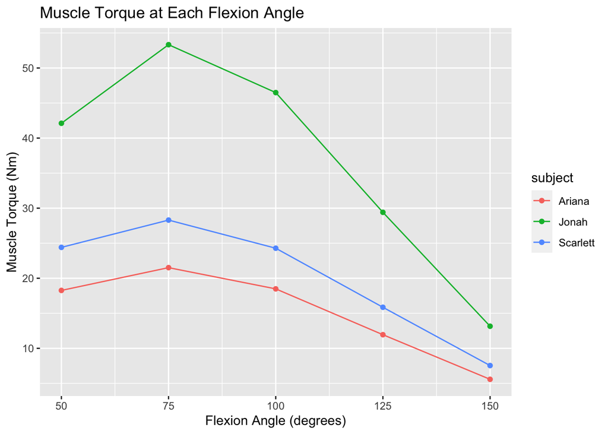

```r
# Plot muscle torque for each flexion angle for each subject
ggplot(dat_final, aes(x = flexion_deg, y = muscle_torque, group = subject, color = subject)) +
  geom_line() +
  geom_point() +
  labs(title = "Muscle Torque at Each Flexion Angle",
       x = "Flexion Angle (degrees)",
       y = "Muscle Torque (Nm)")
```

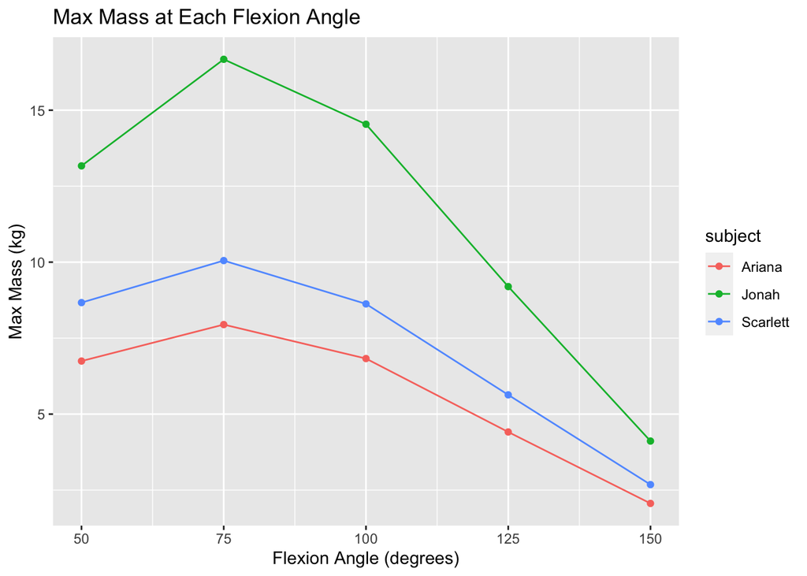

```r
# Plot max mass for each flexion angle for each subject
ggplot(dat_final, aes(x = flexion_deg, y = max_mass, group = subject, color = subject)) +
  geom_line() +
  geom_point() +
  labs(title = "Max Mass at Each Flexion Angle",
       x = "Flexion Angle (degrees)",
       y = "Max Mass (kg)")
```

# Discussion

The predicted muscle torque and Mload values at each flexion angle are displayed in both the table and graphs above. The data shows a trend where muscle torque and max mass generally peak around 75 degrees of flexion for all three subjects, indicating an optimal angle for force generation due to favorable muscle length-tension relationships and lever mechanics. Beyond this angle, both torque and mass support capability decrease, likely due to reduced leverage and less effective muscle contraction angles. This pattern highlights the significance of biomechanics in understanding physical performance.

In gym testing, we were on average able to lift more than the model predicted. Ari was able to lift approximately 2.3 kg above the calculated max mass, and Scarlett was able to lift approximately 2.5 kg above the calculated max mass. Opposite of two participants, Jonah lifted approximately 2.7 kg under the predicted max mass. This could be due to over approximation of bicep mass in addition to inaccurate conversion when at the gym.

This discrepancy could be due to the model not accounting for synergistic muscle actions, neural adaptations, individual biomechanical differences, and psychological factors that can enhance performance. Essentially, real-world performance can exceed model predictions due to the complex interplay of physiological and psychological factors not fully captured by the model. Additionally, other muscles present in the upper arm and shoulder could have compensated for the bicep and aided in the lifting, resulting in participants being able to lift on average a heavier mass than predicted.

Many advancements have been made in the the analysis of musculoskeletal systems, including the Hill-type muscle model studied by Hill (1938) and the force and muscle length approximation equation studied by Whiting and Herzog (1999). However our data shows how more research must be done in order to better analyze and predict how skeletal geometry and muscle length and mass affect both the force output in the forelimb and the maximum load it can support.

# References

Hill, Archibald Vivian. 1938. “The Heat of Shortening and the Dynamic Constants of Muscle.” *Proceedings of the Royal Society of London. Series B-Biological Sciences* 126 (843): 136–95.

Whiting, B, and W Herzog. 1999. *Theoretical Models of Skeletal Muscle: Biological and Mathematical Considerations*. Chichester: Wiley.